# StatCrunch Chapter 2

#### Working with Team Batting Data

To illustrate the construction of several graphs and summaries for a single batch of data, I read in the 2015 team batting data stored in the StatCrunch file TSUB case 2.1.

[figure not shown]

#### Stemplot

Suppose I want to construct a stemplot of the number of triples of all teams.

I open up the Graph menu:

[figure not shown]

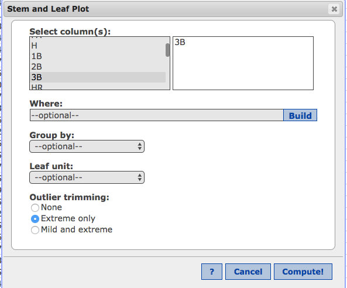

I see a stemplot where the leaf value is the one’s place.

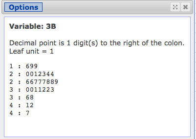

#### Other Plots (dotplot and histogram)

We can construct alternative displays by other choices from the Graph menu.

Here I choose the dotplot option and the variable 3B to get a dotplot of these team triple counts.

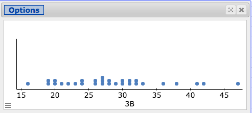

Or I might perfer a histogram – choose Histogram from the main menu.

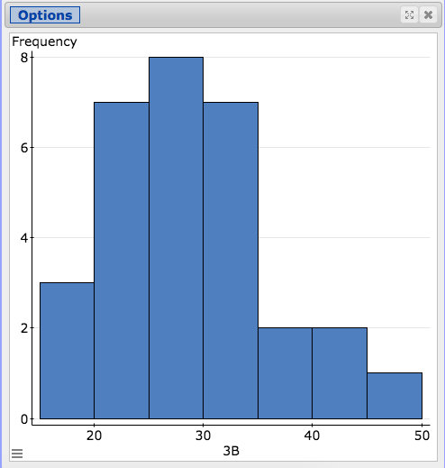

#### Summaries

If we want to compute summaries, say a five-number summary, of the triple counts, then we choose Summary Stats from the Stat menu.

[figure not shown]

By choosing the Summary Stats -> Columns, and then choosing the variable 3B, then we get a collection of different summary statistics for triples include the five number summary(Min, Q1, Median, Q3, Max).

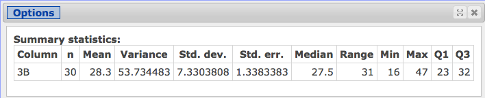